# generalizeR Tutorial

## Step 4: Weighting

The main purpose of this function is to weight the sample so it can provide an unbiased estimate of the total average treatment effect (TATE). If the data is disjoint, then the weighting method is inverse odds; if the data is **not** disjoint, then the weighting method is inverse probability. There is no guided version for this function. Check the function documentation to see which arguments `weighting()` takes - they are the same arguments that `assess()` takes for the most part.

I will run `weighting()` with the `inference_pop`, which I created for `assess()`. You also have the option to add in an `outcome` and `treatment_indicator` variable, in which case, weighting will also calculate the weighted and unweighted TATE. You must include those variables if you want the weighted TATE. Note that you can only include those variables after the study has finished.

```r
selection_covariates <- c("total", "pct_black_or_african_american", "pct_white", "pct_female", "pct_free_and_reduced_lunch")
weighting_output <- weighting(inference_pop_sample, sample_indicator = "sample",covariates = selection_covariates, disjoint_data = F)
```

If you do not include `outcome` and `treatment` variables, then running `summary(weighting_output)` will look like the following.

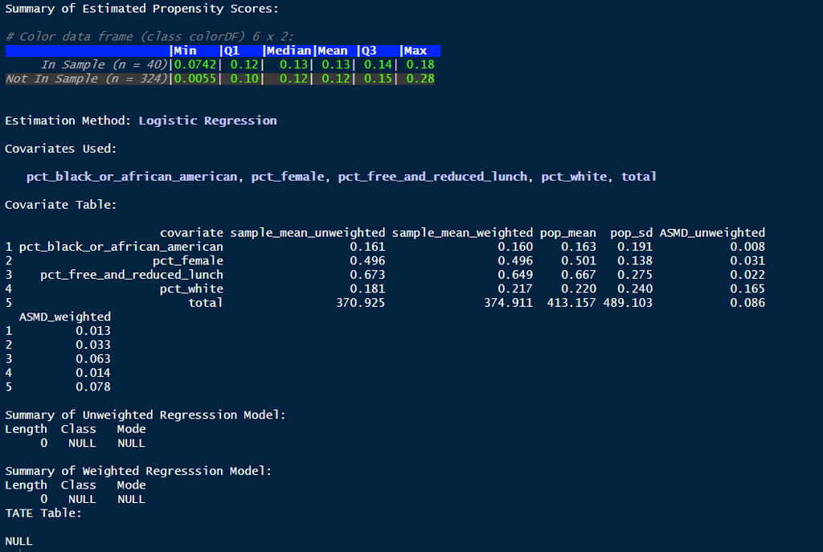

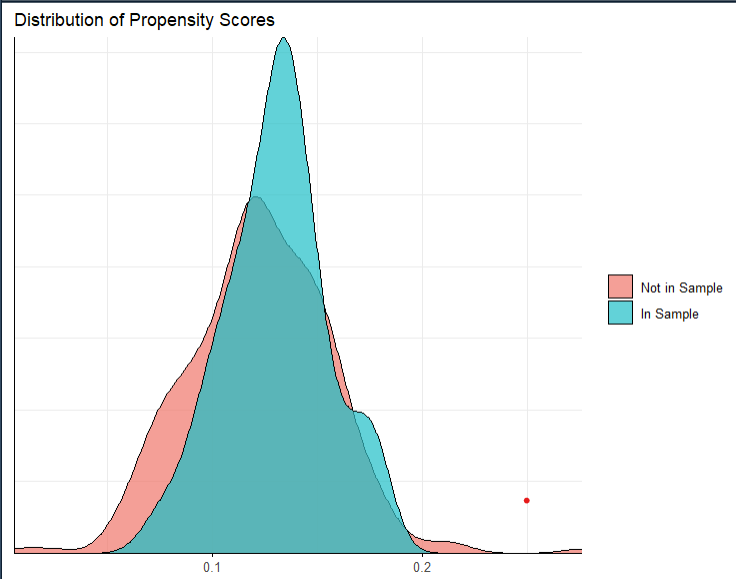

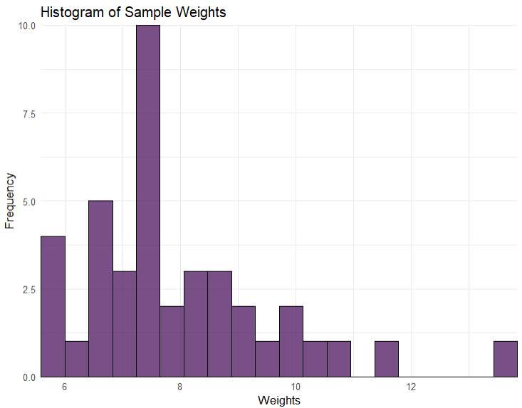

As you can see, these results are similar to the results of `assess()`, with the addition of the histogram describing the distribution of the weights for each unit.

If you do include the `outcome` and `treatment` variables, then you will also get the following tables instead of `NULL` values.

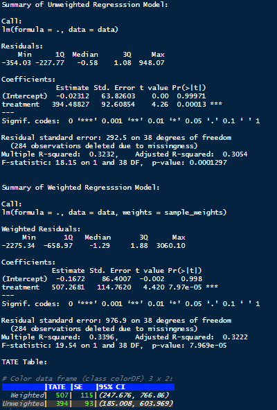

Here, we can see that the weighted TATE is larger than the unweighted TATE. Their confidence intervals overlap, so we cannot conclude that there is a significant difference. We can, however, be confident that the weighted TATE has less bias than the unweighted TATE.

Lastly, you can see a nicer version of the covariate table by running `weighting_output$covariate_kable`.

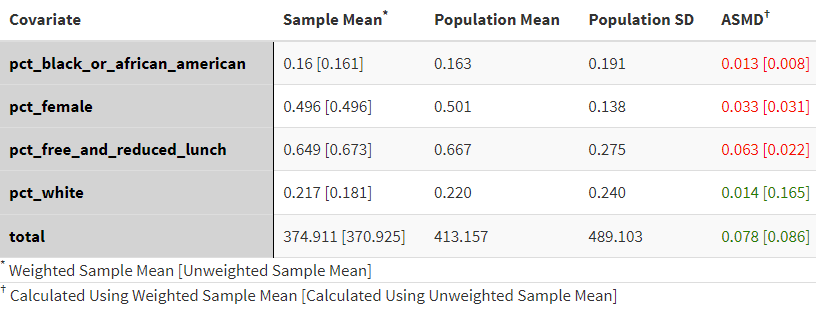